# Вариационный анализ канцерогенного риска

Формула для расчета **индивидуального канцерогенного риска** следующая: R<sub>инд.канц.</sub> = LADD<sub>пер.</sub> ‧ SF

где SF – фактор канцерогенного потенциала $\left[\frac{мг}{кг\cdotсутки}\right]$

Таблица 1. Стандартные факторы экспозиции, используемые при расчете дозы, и их вариабельность при анализе неопределенности

И вопрос сразу же. Почему вроде бы как формула одна и та же, но параметр V в ней имеет разный смысл. По хорошему надо поменять.

| Параметр | Характеристика | Тип распределения | Вариабельность (доверительный интервал значений) |
| --- | --- | --- | --- |
| V | Суточное пероральное поступление почвы в организм взрослого человека, мг/день | константа | 100 |
| EF | частота воздействия, дней/год | триангулярное | 270 (180-365) |
| ED | продолжительность воздействия, лет | логнормальное | 30 (19-43) |
| BW | масса тела, кг | логнормальное | 70 (55-80) |
| AT | период осреднения экспозиции, лет | константа | 70 |
| $C_{эл}$ | концентрация элемента, $мг/м^3$ | нормальное | $C_{эл}$ ± SD |

Задаем факторы канцерогенного потенциала SF для каждого из веществ. А также средствами языка R задаем остальные коэффициенты, входящие в формулу расчета R<sub>инд.канц.</sub> с соответствующими распределениями из таблицы 1, и концентрации элементов также в виде распределения. Распределение концентраций будем моделировать с теми же параметрами, полученными из расчета среднего и ошибки реальных концентраций этих элементов в 10 пробах г. Междуреченска за 2015 год.

В этом наборе данных поменяем вручную значения выбросов. Cr: 72.93 79.73 77.32 точки 7,9,10. А мышьяка (As): 25.15 точка 6, у Pb 30.43, 39.72 точки 9, 10

Факторы канцерогенного потенциала (SF) при пероральном поступлении, используемые для расчета: Be = 4.3, Cr = 0.42, As = 1.5, Cd = 0.38, Pb = 0.047

Таблица с данными имеет вид:

| Be | Cr | As | Cd | Pb |
| --- | --- | --- | --- | --- |
| 1.24 | 111.1715 | 31.93395 | 0.13 | 57.63714 |
| 1.91 | 85.3054 | 13.57307 | 0.32 | 75.20592 |
| 1.53 | 94.0501 | 20.35125 | 0.21 | 34.12346 |
| 1.53 | 97.2028 | 18.86260 | 0.33 | 59.71779 |
| 2.06 | 98.7364 | 33.01233 | 0.29 | 69.48009 |
| 1.72 | 103.2297 | 23.58877 | 1.19 | 68.93844 |
| 2.26 | 91.7673 | 31.74593 | 0.29 | 58.00743 |
| 1.69 | 98.3656 | 34.68804 | 0.33 | 42.93861 |
| 2.45 | 85.3735 | 23.25920 | 1.07 | 61.66451 |
| 1.99 | 100.2685 | 19.44518 | 0.85 | 65.73095 |

Средние значения и ошибка (SD) концентраций элементов для проверки

| Be | Cr | As | Cd | Pb |
| --- | --- | --- | --- | --- |
| 1.83800 | 96.54708 | 25.04603 | 0.50100 | 59.34443 |
| 0.36718 | 7.89666 | 7.28280 | 0.38339 | 12.48387 |

Моделируем распределение концентраций элементов с полученными средними и дисперсией, подставляем в формулу для LADD и все перемножаем (не забываем умножить на 10<sup>-6</sup>).

Средние значения и ошибка LADD при расчете с учетом коэффициентов и концентраций в виде распределения

| Be | Cr | As | Cd | Pb |
| --- | --- | --- | --- | --- |
| 1.00691e-06 | 5.24881e-05 | 1.37603e-05 | 2.70424e-07 | 3.24668e-05 |
| 5.60341e-07 | 2.73768e-05 | 8.19221e-06 | 2.54379e-07 | 1.89309e-05 |

Дальше считаем R<sub>инд.канц.</sub>, Умножаем полученные LADD на SF.

Средние значения и ошибка R<sub>инд.канц.</sub>

| Be | Cr | As | Cd | Pb |
| --- | --- | --- | --- | --- |
| 4.32970e-06 | 2.20450e-05 | 2.06405e-05 | 1.02761e-07 | 1.52594e-06 |
| 2.40947e-06 | 1.14983e-05 | 1.22883e-05 | 9.66639e-08 | 8.89754e-07 |

### Уровни R<sub>инд.канц.</sub> для соответствующих вероятностей

|  | Be | Cr | As | Cd | Pb |
| --- | --- | --- | --- | --- | --- |
| 25% | 2.7e-06 | 1.45e-05 | 1.21e-05 | 0e+00 | 9.0e-07 |
| 50% | 3.7e-06 | 1.96e-05 | 1.80e-05 | 1e-07 | 1.4e-06 |
| 75% | 5.4e-06 | 2.71e-05 | 2.58e-05 | 1e-07 | 1.8e-06 |

Для построения на графике домножим все значения на 1Е6

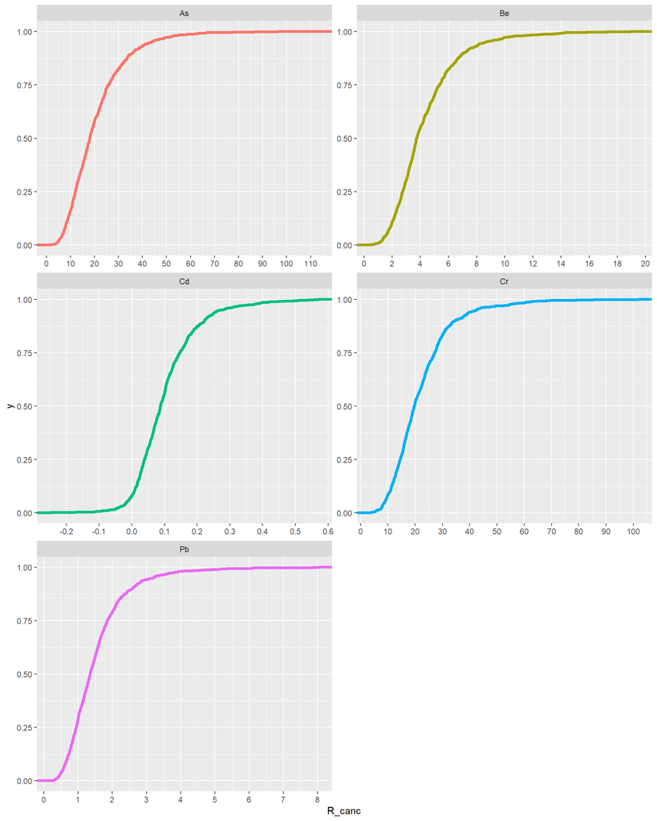